# Table of Contents

# Projet 4 (Data aanlyste V1) : Analyse de vente d'une librairie

Ce notebook est consacré à l'anlyse proporement dite du jeu de donnée nettoyé dans la mission 1 du projet 4.Il s'appuiera sur des indiccateurs precis pour sortirr des informations clés issues d'une exploitation fine des données. Ci-dessous les differentes analyses demandées pour valider ce projet.

# Mission 2 : Analyses

Cette mission sera realisée en nous appuyant sur les ressources diverses d'openclassroom et autres du langage python et ses differentes librairies dediées à la data analyse. Pour ce faire, nous commencons par importer les librairies recquises .

# #Exploration de la table

```python
#Importons  les  librairies requises
import pandas as pd
import  numpy as  np
import seaborn as sns
import matplotlib.pyplot as plt
import scipy.stats as st

#Ces differents  packages et librairies  de  Python  nous  permettront de realiser les analyses.
```

```python
#En fin de  mission 1 (document  joint dans  le dossier final), nous avons  converti  notre dataframe en  csv
datap4 = pd.read_csv('datap4')

#Ainsi,  nous chargeons  ce fichier csv et transformons certaines de ces colonnes
#Nous transformons la colonne date  en  un format recquis (normalisation)
datap4['date'] = pd.to_datetime(datap4['date'],infer_datetime_format = True,
                                              errors='coerce')

#Ensuite  , nous faisons  une  premiere analyse de  notre table
datap4.info()
datap4.head()
```

```
<class 'pandas.core.frame.DataFrame'>
RangeIndex: 336713 entries, 0 to 336712
Data columns (total 10 columns):
 #   Column      Non-Null Count   Dtype
---  ------      --------------   -----
 0   Unnamed: 0  336713 non-null  int64
 1   id_prod     336713 non-null  object
 2   price       336713 non-null  float64
 3   categ       336713 non-null  float64
 4   date        336713 non-null  datetime64[ns]
 5   session_id  336713 non-null  object
 6   client_id   336713 non-null  object
 7   sex         336713 non-null  object
 8   birth       336713 non-null  int64
 9   datebis     336713 non-null  object
dtypes: datetime64[ns](1), float64(2), int64(2), object(5)
memory usage: 25.7+ MB
```

|  | Unnamed: 0 | id_prod | price | categ | date | session_id | client_id | sex | birth | datebis |
| --- | --- | --- | --- | --- | --- | --- | --- | --- | --- | --- |
| 0 | 0 | 0_1483 | 4.99 | 0.0 | 2021-04-10 18:37:28.723910 | s_18746 | c_4450 | f | 1977 | 2021-04-10 18:37:28.723910 |
| 1 | 1 | 0_1483 | 4.99 | 0.0 | 2021-12-27 11:11:12.123067 | s_140787 | c_5433 | f | 1981 | 2021-12-27 11:11:12.123067 |
| 2 | 2 | 0_1483 | 4.99 | 0.0 | 2021-10-27 04:56:38.293970 | s_110736 | c_857 | m | 1985 | 2021-10-27 04:56:38.293970 |
| 3 | 3 | 0_1483 | 4.99 | 0.0 | 2021-07-04 06:43:45.676567 | s_57626 | c_3679 | f | 1989 | 2021-07-04 06:43:45.676567 |
| 4 | 4 | 0_1483 | 4.99 | 0.0 | 2021-09-19 08:45:43.735331 | s_92165 | c_1609 | m | 1980 | 2021-09-19 08:45:43.735331 |

```python
#Supprimons  la colonne datebis dont  on a  plus besoin
datap4V = datap4.drop(columns = ['datebis','Unnamed: 0'])
datap4V.head()
```

|  | id_prod | price | categ | date | session_id | client_id | sex | birth |
| --- | --- | --- | --- | --- | --- | --- | --- | --- |
| 0 | 0_1483 | 4.99 | 0.0 | 2021-04-10 18:37:28.723910 | s_18746 | c_4450 | f | 1977 |
| 1 | 0_1483 | 4.99 | 0.0 | 2021-12-27 11:11:12.123067 | s_140787 | c_5433 | f | 1981 |
| 2 | 0_1483 | 4.99 | 0.0 | 2021-10-27 04:56:38.293970 | s_110736 | c_857 | m | 1985 |
| 3 | 0_1483 | 4.99 | 0.0 | 2021-07-04 06:43:45.676567 | s_57626 | c_3679 | f | 1989 |
| 4 | 0_1483 | 4.99 | 0.0 | 2021-09-19 08:45:43.735331 | s_92165 | c_1609 | m | 1980 |

```python
#Explorons notre table avant  les analyses
# avec la methhode describe
datap4V.describe(include ='all')
```

|  | id_prod | price | categ | date | session_id | client_id | sex | birth |
| --- | --- | --- | --- | --- | --- | --- | --- | --- |
| count | 336713 | 336713.000000 | 336713.000000 | 336713 | 336713 | 336713 | 336713 | 336713.000000 |
| unique | 3264 | NaN | NaN | 336713 | 169173 | 8600 | 2 | NaN |
| top | 1_369 | NaN | NaN | 2021-06-30 11:35:55.387896 | s_118668 | c_1609 | m | NaN |
| freq | 1081 | NaN | NaN | 1 | 14 | 12855 | 169198 | NaN |
| first | NaN | NaN | NaN | 2021-03-01 00:01:07.843138 | NaN | NaN | NaN | NaN |
| last | NaN | NaN | NaN | 2022-02-28 23:59:58.040472 | NaN | NaN | NaN | NaN |
| mean | NaN | 17.215189 | 0.430156 | NaN | NaN | NaN | NaN | 1977.823568 |
| std | NaN | 17.855445 | 0.591082 | NaN | NaN | NaN | NaN | 13.524433 |
| min | NaN | 0.620000 | 0.000000 | NaN | NaN | NaN | NaN | 1929.000000 |
| 25% | NaN | 8.610000 | 0.000000 | NaN | NaN | NaN | NaN | 1971.000000 |
| 50% | NaN | 13.900000 | 0.000000 | NaN | NaN | NaN | NaN | 1980.000000 |
| 75% | NaN | 18.990000 | 1.000000 | NaN | NaN | NaN | NaN | 1987.000000 |
| max | NaN | 300.000000 | 2.000000 | NaN | NaN | NaN | NaN | 2004.000000 |

Nous observons des variables quantitatives et qualitatives.

```python
#Coninuons d'explorer  notre  table
#En verifiant pr exemple s'il y' a  pas des doublons
datap4V.duplicated().sum()
```

```
0
```

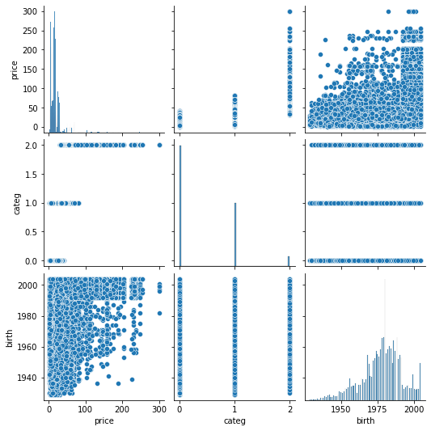

```python
#Visualisons  brievement  l'ensemble de  nos variables
sns.pairplot(datap4V)
#Une  rapide  visualisation  nous  revele quelques details sur  les variables notamment quantitatives à part  categ
#On  peut remarquer  que  les  plus  jeunes  achètent  plus de  livres
```

Une premiere exploration de notre table indique qu'il n' ya plus de doublons mais aussi que nous avons des variables quantitatives et qualitatives avec des specificites comme la variable date qui est qualitative ordinale. A present , nous pouvons proceder analyses à travers les indicateurs statistiques de la statistique descriptive.

# #Analyses univariées

Nous allons tester les indicateurs statistiques sur les variables importantes à nos yeux prises individuellement. Ces differents indicateurs seront sollicités pour l'analyse univariée: -les mesures de tendence centrale -les mesures de dispersion -les mesures de forme -les mesures de concentration Nous allons commencer par analyser les variables categ et price

# Variable birth

```python
#Appliquons des mesures de  tendance centrale  et de dispersion  sur cette varible quantitative
''
print('Moyenne :', datap4V['birth'].mean(),';Mediane :' , datap4V['birth'].median(),' ; Mode : ',datap4V['birth'].mode(),';Variance:',datap4V['birth'].var(ddof=0))
```

```
Moyenne : 1977.8235678456133 ;Mediane : 1980.0  ; Mode :  0    1980
dtype: int64 ;Variance: 182.90975309833988
```

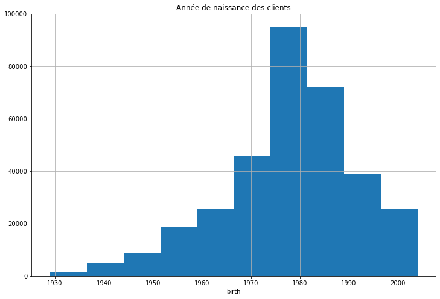

```python
#Affichons l' histogramme de la variable  birth
plt.figure(figsize=(12,8))
datap4V['birth'].hist()
plt.title('Année de naissance des clients')
plt.xlabel('birth')
plt.show()
plt.savefig('naissance des  clients.jpg')
```

```python
#Nous allons  creer  une  nouvelle colonne  pour  inscrire  les ages des clients
#Creons  la colonne  age pour appliquer  nos  operations futures

datap4V['age']= 2021-datap4V['birth'] #Une soustraction à partir des années de  naissance nous  permets de creer les valeurs de  la colonne  age
datap4V.head()
```

|  | id_prod | price | categ | date | session_id | client_id | sex | birth | age |
| --- | --- | --- | --- | --- | --- | --- | --- | --- | --- |
| 0 | 0_1483 | 4.99 | 0.0 | 2021-04-10 18:37:28.723910 | s_18746 | c_4450 | f | 1977 | 44 |
| 1 | 0_1483 | 4.99 | 0.0 | 2021-12-27 11:11:12.123067 | s_140787 | c_5433 | f | 1981 | 40 |
| 2 | 0_1483 | 4.99 | 0.0 | 2021-10-27 04:56:38.293970 | s_110736 | c_857 | m | 1985 | 36 |
| 3 | 0_1483 | 4.99 | 0.0 | 2021-07-04 06:43:45.676567 | s_57626 | c_3679 | f | 1989 | 32 |
| 4 | 0_1483 | 4.99 | 0.0 | 2021-09-19 08:45:43.735331 | s_92165 | c_1609 | m | 1980 | 41 |

```python
#Pour  avoir des  informations  pertinentes  , nous allons  regrouper  les années de naissance  en  classe
#Cela nous  permettra di subdiviser et d'affecter  les ages en des cllases  pour  une  meilleure analyse
datap4V['ageclas'] = pd.cut(x= datap4V['age'], bins= [20,30,40,50,60,70])
datap4V.head()
```

|  | id_prod | price | categ | date | session_id | client_id | sex | birth | age | ageclas |
| --- | --- | --- | --- | --- | --- | --- | --- | --- | --- | --- |
| 0 | 0_1483 | 4.99 | 0.0 | 2021-04-10 18:37:28.723910 | s_18746 | c_4450 | f | 1977 | 44 | (40, 50] |
| 1 | 0_1483 | 4.99 | 0.0 | 2021-12-27 11:11:12.123067 | s_140787 | c_5433 | f | 1981 | 40 | (30, 40] |
| 2 | 0_1483 | 4.99 | 0.0 | 2021-10-27 04:56:38.293970 | s_110736 | c_857 | m | 1985 | 36 | (30, 40] |
| 3 | 0_1483 | 4.99 | 0.0 | 2021-07-04 06:43:45.676567 | s_57626 | c_3679 | f | 1989 | 32 | (30, 40] |
| 4 | 0_1483 | 4.99 | 0.0 | 2021-09-19 08:45:43.735331 | s_92165 | c_1609 | m | 1980 | 41 | (40, 50] |

# Variable categ

```python
#Comptons  le nombre de valeurs selon les modalités de  categ
datap4V["categ"].value_counts()
```

```
0.0    209426
1.0    109735
2.0     17552
Name: categ, dtype: int64
```

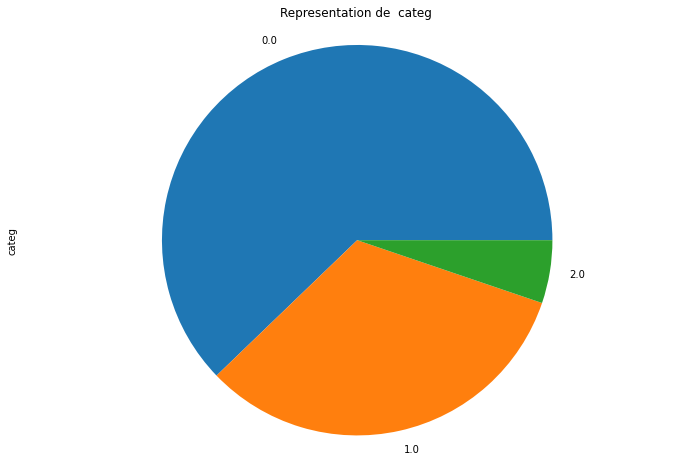

```python
#Nous  pouvons afficher  un diagramme en secteur de cette variable aussi
plt.figure(figsize=(12,8))
datap4V["categ"].value_counts(normalize=True).plot(kind='pie')
plt.axis('equal')
plt.title('Representation de  categ')
plt.savefig('categ en diagramme de secteurs.jpg')
plt.show()
#La categorie 0 de produit  est la  plus representée dans  la distribution de cette variable suivie de  la categ 1.
```

# Variable price

```python
#Appliquons des mesures de  tendance centrale  et de dispersion  sur cette varible quantitative
''
print('Moyenne :', datap4V['price'].mean(),';Mediane :' , datap4V['price'].median(),' ; Mode : ',datap4V['price'].mode(),';Variance:',datap4V['price'].var(ddof=0))
```

```
Moyenne : 17.21518851371992 ;Mediane : 13.9  ; Mode :  0    15.99
dtype: float64 ;Variance: 318.8159827837277
```

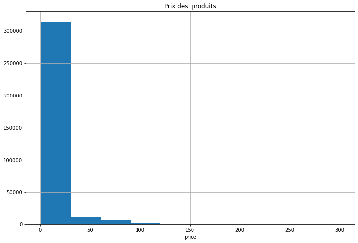

```python
#Affichons  la representation graphique de cette variable
plt.figure(figsize=(12,8))
datap4V['price'].hist()
plt.title('Prix des  produits')
plt.xlabel('price')
plt.show()
plt.savefig('prix des articles .jpg')
#On remarque que  les  prix des articles tournant autour de  20€ avec  une  plus grande valeur tournant  autour de 15€
```

# Sous echantillonage 1 categ-price

Après avoir etudié individuellement certaines variables de notre distribution , nous decidons d'observer ces variables en creant un sous-echantillon dans table complete afin de tester les indicateurs de la statistique descriptive. Nous commencons de prime abord par un binome de categ et de price

# Variables categ et price

Nous allons tester une variable qualitative avec une quantitative et y tester des indiateurs de tendance centrale en premier en creant un sous echantillon .

# Mesures de tendance centrale

Pour une premiere analyse, nous testons les mesures de tendance centrale sur les deux variables . Cela nous permettra d'observer ces deux variables .

```
--------------------
0.0
moy:
 10.646828235274794
med:
 9.99
mod:
 0    4.99
dtype: float64
```

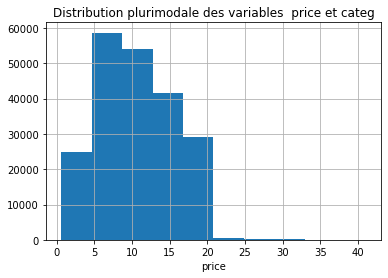

```
--------------------
1.0
moy:
 20.48010580034348
med:
 19.08
mod:
 0    15.99
dtype: float64
```

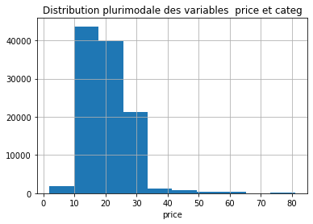

```
--------------------
2.0
moy:
 75.17494929352172
med:
 62.83
mod:
 0    68.99
dtype: float64
```

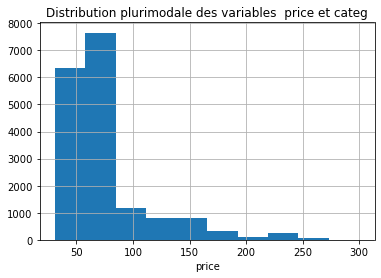

```python
#Nous testons  les variables categ  et  price à travers  les  mesures de  tendance centrale que sont  la moyenne, la mediane  et le  mode  .
#Pour cela  nous definissons  une boucle , un sous-echantillon et affichons  les representations graphiques
#La creation d'un sous-echantillon  permet  d'evaluer et de comparer les  prix des  produits par  categorie
for cat in datap4V["categ"].unique():
    subset = datap4V[datap4V.categ == cat] # Création du sous-échantillon
    print("-"*20)
    print(cat)
    print("moy:\n",subset['price'].mean())
    print("med:\n",subset['price'].median())
    print("mod:\n",subset['price'].mode())
    subset["price"].hist() # Crée l'histogramme
    plt.title('Distribution plurimodale des variables  price et categ')
    plt.xlabel('price')
    plt.figure(figsize=(12,8))
    plt.show() # Affiche l'histogramme
    plt.savefig('Mesures de tendance centrale des variables categ et price.jpg')#sauvegarde les images

#Ce code  nous  permet d'observer plusieurs mesures de tendance centrale
```

# Interpretation Tendnace centrale

## Interpretation

Nous observons une distribution plurimodale avec trois modes differents selons les categories Nous intrepretons cela comme plusieurs types de produit de livres vendus par l'entreprise; Les representations graphiques montrent une distribution oblique à droite qui peuvent indiquer des comportements d'achat pas très unifirmes. Dans la categ 2 on observe un plus grand etalement des valeurs avec des valeurs extrèmes importantes. Le prix des produits dans les differentes categories peuvent nous permettre de classer les livres en produits : -d'appel -de moyen de gamme -et produit haut de gamme Constat d'une forte proportion de valeurs dans la 1 ere moitié de la distribution

# Mesures de dispersion

# Nous allons tester les deux variables avec les mesures de variance et d'ecart-type

```
--------------------
0.0
moy:
 10.646828235274794
med:
 9.99
mod:
 0    4.99
dtype: float64
var:
 24.305077486351436
ect:
 4.9300180006113
```

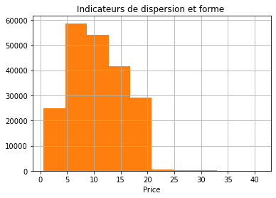

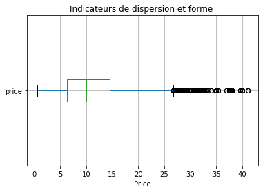

```
--------------------
1.0
moy:
 20.48010580034348
med:
 19.08
mod:
 0    15.99
dtype: float64
var:
 57.28857407274124
ect:
 7.5689215924556414
```

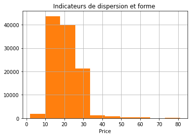

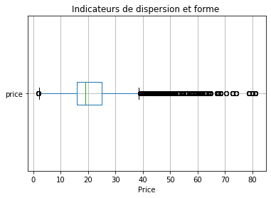

```
--------------------
2.0
moy:
 75.17494929352172
med:
 62.83
mod:
 0    68.99
dtype: float64
var:
 1527.1592950064896
ect:
 39.0788855394635
```

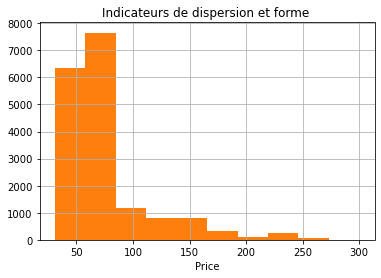

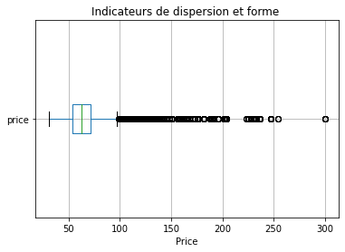

```python
#Teestons  ces autres  mesures  univariées
for cat in datap4V["categ"].unique():
    subset = datap4V[datap4V.categ == cat] # Création du sous-échantillon
    print("-"*20)
    print(cat)
    print("moy:\n",subset['price'].mean())
    print("med:\n",subset['price'].median())
    print("mod:\n",subset['price'].mode())
    subset["price"].hist() # Crée l'histogramme
    print("var:\n",subset['price'].var(ddof=0))
    print("ect:\n",subset['price'].std(ddof=0))
    subset["price"].hist()
    plt.title('Indicateurs de dispersion et forme ')
    plt.xlabel('Price')
    plt.show()
    subset.boxplot(column="price", vert=False)
    plt.title('Indicateurs de dispersion et forme ')
    plt.xlabel('Price')
    plt.show() # Affiche l'histogramme
```

# Mesures de forme

Nous allons appliquer les mesures de forme a nos variables

```
--------------------
0.0
moy:
 10.646828235274794
med:
 9.99
mod:
 0    4.99
dtype: float64
var:
 24.305077486351436
ect:
 4.9300180006113
skw:
 0.4265179632997088
kur:
 -0.37370825885260794
```

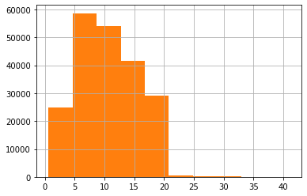

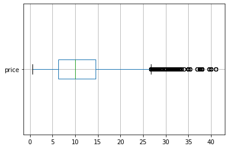

```
--------------------
1.0
moy:
 20.48010580034348
med:
 19.08
mod:
 0    15.99
dtype: float64
var:
 57.28857407274124
ect:
 7.5689215924556414
skw:
 1.727288185296097
kur:
 8.15419252528647
```

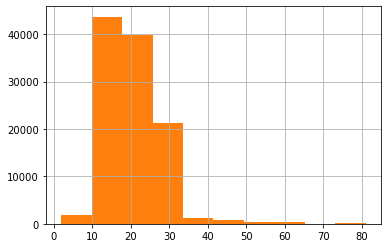

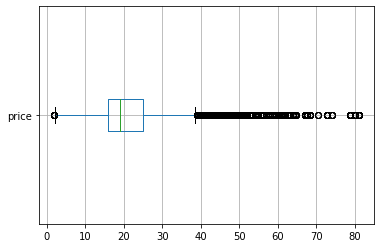

```
--------------------
2.0
moy:
 75.17494929352172
med:
 62.83
mod:
 0    68.99
dtype: float64
var:
 1527.1592950064896
ect:
 39.0788855394635
skw:
 2.315631002662296
kur:
 5.537461225837999
```

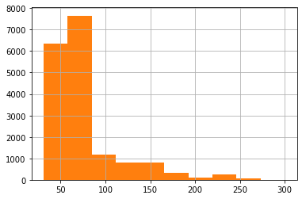

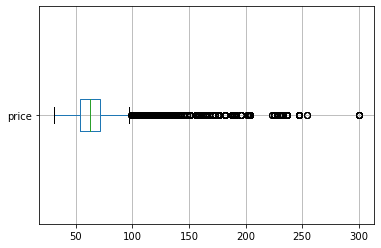

```python
#Testins 3 mesure de forme
for cat in datap4V["categ"].unique():
    subset = datap4V[datap4V.categ == cat] # Création du sous-échantillon
    print("-"*20)
    print(cat)
    print("moy:\n",subset['price'].mean())
    print("med:\n",subset['price'].median())
    print("mod:\n",subset['price'].mode())
    subset["price"].hist() # Crée l'histogramme
    print("var:\n",subset['price'].var(ddof=0))
    print("ect:\n",subset['price'].std(ddof=0))
    print("skw:\n",subset['price'].skew())
    print("kur:\n",subset['price'].kurtosis())
    subset["price"].hist()
    plt.show()
    subset.boxplot(column="price", vert=False)
    plt.show() # Affiche l'histogramme
```

# Interpretation mesures de dispersion et de forme

# Synthèse 1

Cette premiere analyse indique une distribution plurimodale avec des modes differents et des dispersions de valeurs montrant des valeurs extremes au sein d'une meme categorie de produits. Cela pourrait indiquer une typologie de produits avec des produits d'appel , d'enrée de gamme et des produits moyen et hauts de gamme.

# Sous echantillonge 2 categ-birth

Nous avons appliqué les indicateurs de statistique descriptive sur ce binome pour en comprendre les structurants.

```
--------------------
0.0
moy:
 1978.102279564142
med:
 1980.0
mod:
 0    1980
dtype: int64
var:
 125.52194651922915
ect:
 11.20365772947519
skw:
 -1.0182808742924057
kur:
 1.8048203074679527
```

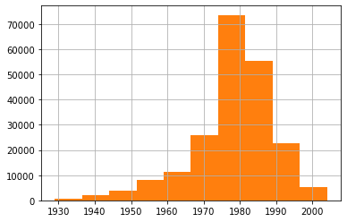

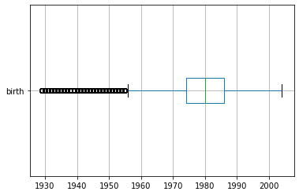

```
--------------------
1.0
moy:
 1974.3408757461157
med:
 1975.0
mod:
 0    1980
dtype: int64
var:
 240.48004011337127
ect:
 15.507418873344825
skw:
 -0.19020060653030443
kur:
 -0.4109229160973551
```

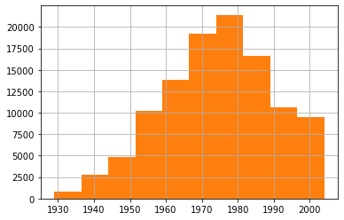

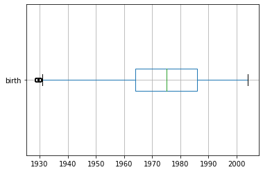

```
--------------------
2.0
moy:
 1996.271820875114
med:
 1999.0
mod:
 0    2004
dtype: int64
var:
 90.6211339223354
ect:
 9.519513323817316
skw:
 -3.0109521274078053
kur:
 10.81193458964021
```

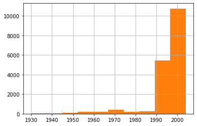

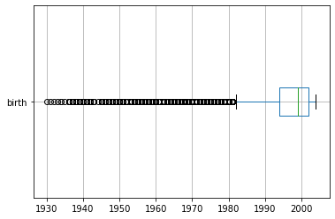

```python
#Nous testons  nos differents indicateurs en couplant  les variables categ  et  birth
for cat in datap4V["categ"].unique():
    subset = datap4V[datap4V.categ == cat] # Création du sous-échantillon
    print("-"*20)
    print(cat)
    print("moy:\n",subset['birth'].mean())
    print("med:\n",subset['birth'].median())
    print("mod:\n",subset['birth'].mode())
    subset["birth"].hist() # Crée l'histogramme
    print("var:\n",subset['birth'].var(ddof=0))
    print("ect:\n",subset['birth'].std(ddof=0))
    print("skw:\n",subset['birth'].skew())
    print("kur:\n",subset['birth'].kurtosis())
    subset["birth"].hist()
    plt.show()
    subset.boxplot(column="birth", vert=False)
    plt.show() # Affiche l'histogramme
```

# Synthèse 2

Les differents indicateurs indiquent des mesures de tendance centrale presqu'identique pour les cate 0 et 1 . Cependant la categ 2 se demarque sur les differnts indicateurs statistiques. On peut y lire par exemple que c'est les jeunes qui achentent le plus.Ainsi la boxplot montre des outliers ou valeurs extremes se positionnat avant le 1 er quartile mais l'ensemble des valeurs de naissance tourne autour des années 2000 d'où le mode à 2004. Enfin nous observons une asymetrie qui plenche du coté gauche dont une asymetrie negative.

# Interpretation generale partielle

Les nalyses univariées nous indiquent quelques tendances notamment sur la propension des plus jeunes à acheter davantage que les moins jeunes. Aussi nous pouvons classer les produits en produits d'appel pour ceux de la categ 0 , en produit de moyen de gamme pour la categ 1 et en produit haut de gamme pour categ 2 vu les pris moyens de cette categorie autour de 70 €. Mais les prix moyens sont à relativiser car ils subissent l'impact de valeurs dispersées et extremes constatées . Enfin ,la distribution plurimodale peut nous reveler de prendre en consideration les differentes categories afin de segmenter plis tard le portefeuille clientèle. Mais l'analyse univariée est limitée pour mieux decrire notre echantillon .